# Transcriptomics: Idopathic Pulmonary Fibrosis (IPF)

In this notebook I will analyse differences in gene expression between samples of IPF and healty lung tissues.

[Link to the data](https://www.ncbi.nlm.nih.gov/geo/query/acc.cgi?acc=GSE150910)  
This is my first project learning bioinformatics, it is generally wiser to use an R package like DESeq2, edgeR or Lima-Voom. This analysis is based on Mike Saint-Antoine Bioinformatics tutorial series.

## Importing the libraries required for the analysis

```python
import numpy as np
import pandas as pd
import random
import matplotlib.pyplot as plt
from scipy.stats import ks_2samp
import seaborn as sns
```

## Reading data using Pandas and converting to numpy arrays

Pandas is a Python library designed for efficient data loading and manipulation, especially for structured formats such as CSV or Excel files. It offers high-level data structures like DataFrames, which simplify data handling and preprocessing. These structures can be easily converted into NumPy arrays for downstream numerical analysis.

```python
samples = []
genes = []
data = []
filepath = "./GSE150910_gene-level_count_file.csv"

df = pd.read_csv(filepath)

samples = df.columns[1:].to_numpy() # name of the samples (columns)
genes = df.iloc[:, 0].to_numpy() # name of the genes (rows)
data = df.iloc[:, 1:].to_numpy().astype(np.float32) # 18838 x 288 matrix of data for each gene of each sample

# checking the shape of our data
print(samples.shape)
print(genes.shape)
print(data.shape)
```

```
(288,)
(18838,)
(18838, 288)
```

## Filtering out Chronic Hypersensitivity Pneumositis (CHP)

CHP cases are out of scope for this notebook, hence we need to filter them out of the samples used for the analysis.

```python
labels = []

# creating a numpy array containing the prefix of the condition: "ipf", "chp", "control"
for i in range(len(samples)):
    tmp = samples[i].split("_")
    labels.append(tmp[0])

labels = np.array(labels)

# filtering our current data based on whether or not it is from a CHP sample
samples = samples[labels != "chp"]
data = data[:, labels != "chp"]
labels = labels[labels != "chp"]

print("Remaining samples have conditions:", np.unique(labels))

# We should notice that the size of our vectors is smaller, since we took out the CHP samples
print(samples.shape)
print(genes.shape)
print(data.shape)
print(data)
```

```
Remaining samples have conditions: ['control' 'ipf']
(206,)
(18838,)
(18838, 206)
[[8.490e+02 1.093e+03 8.440e+02 ... 1.092e+03 6.390e+02 9.440e+02]
 [0.000e+00 0.000e+00 0.000e+00 ... 6.000e+00 0.000e+00 0.000e+00]
 [2.388e+03 2.229e+03 1.492e+03 ... 2.084e+03 1.387e+03 2.150e+03]
 ...
 [4.000e+00 8.000e+00 5.000e+00 ... 1.000e+00 3.000e+00 5.000e+00]
 [5.900e+01 7.600e+01 3.700e+01 ... 5.900e+01 3.700e+01 6.300e+01]
 [0.000e+00 0.000e+00 0.000e+00 ... 0.000e+00 0.000e+00 0.000e+00]]
```

## Normalizing the data using CPM normalization

Normalization is a critical step to ensure comparability between samples. CPM (Counts Per Million) normalization scales raw gene counts by the library size (total reads per sample), thereby correcting for differences in sequencing depth and enabling meaningful comparison of gene expression levels across samples.

```python
for i in range(data.shape[1]):
    column_sum = sum(data[:, i])

    data[:,i] = data[:,i] / column_sum * 1_000_000
```

## Filtering out genes with low expression in both conditions

At this stage, we remove genes that show very low expression levels in both conditions. These genes are unlikely to carry meaningful biological information, as their expression is close to background noise and may reflect technical variability rather than true biological signals.

Filtering them out helps to:

- Reduce noise in the dataset
- Improve the reliability of downstream analyses (e.g., differential expression)
- Decrease the multiple testing burden, thereby increasing statistical power

This step is especially important in transcriptomics studies, such as idiopathic pulmonary fibrosis, where we aim to identify genes that are genuinely involved in disease-related processes rather than artifacts of low signal.

In a more advanced analysis pipeline, additional steps would typically be included, such as:

- More refined filtering strategies
- Data normalization methods
- Batch effect correction
- Integration of metadata (e.g., demographic or clinical variables)
- Detection and careful evaluation of outliers

These steps help ensure that the observed patterns reflect true biological variation rather than technical or experimental biases.

```python
mean_CPM_control = data[:, labels == "control"].mean(axis=1) # mean gene expression value for each control column
mean_CPM_ipf = data[:, labels == "ipf"].mean(axis=1) # mean gene expression value for each ipf column

 # filter out genes that have expression level lower than 5 in CPM to keep only relevant genetic data
to_keep = (mean_CPM_control >= 5) | (mean_CPM_ipf >=5)
data = data[to_keep, :]
genes = genes[to_keep]
```

## Two-sample Kolmogorov–Smirnov test

The Kolmogorov–Smirnov (KS) test is a non-parametric test used to determine whether two samples are drawn from the same underlying distribution.

In our case, we use it to compare gene expression levels between control and IPF samples.

- **Null hypothesis (H₀):** The control and IPF samples are drawn from the same continuous distribution.
- **Alternative hypothesis (H₁):** The two samples are drawn from different distributions.

The KS statistic is defined as the maximum distance between the empirical cumulative distribution functions (ECDFs) of the two samples. A large KS statistic indicates a greater discrepancy between the distributions.

One advantage of this test is that it makes no assumption about the shape of the distribution (non-parametric), making it particularly suitable for gene expression data, which often deviate from normality.

A small p-value leads us to reject the null hypothesis, suggesting that gene expression distributions differ significantly between control and IPF samples.

It is important to note that the KS test is sensitive to any difference between distributions, including differences in mean, variance, or overall shape. For example, two normal distributions with the same mean but different variances will still be detected as significantly different.

While this sensitivity is a strength, it also means that the test does not indicate *which aspect* of the distributions differs. Therefore, additional analyses or visualizations are often needed to interpret the biological relevance of the observed differences.

For the purposes of this study, we use the KS test as a general tool to detect distributional differences between control and IPF gene expression profiles.

```python
p_values = []
log2FCs = []
epsilon = 1

for i in range(data.shape[0]):
    control = data[i, labels == "control"]
    ipf = data[i, labels == "ipf"]
    ks_stat, p_value = ks_2samp(control, ipf)

    p_values.append(p_value)
    # Since the KS test does not indicate which aspect of the distribution differs,
    # we complement it with a measure of central tendency difference between groups.
    # We compute the log2 fold change (log2FC), which compares the mean gene expression
    # between IPF and control samples.

    # First compute the fold change:
    # fold_change = mean(IPF) / mean(control)
    control_mean = np.mean(control)
    ipf_mean = np.mean(ipf)
    fold_change = (ipf_mean + epsilon) / (control_mean + epsilon) # the epsilon here is a small value used to avoid division by 0 errors
    # Then take the logarithm (base 2):
    # log2FC = log2(mean(IPF) / mean(control))
    log2FC = np.log2(fold_change)
    # The log2 transformation makes the measure symmetric around 0:
    # - log2FC > 0 → higher expression in IPF
    # - log2FC < 0 → lower expression in IPF
    # - log2FC = 0 → no difference
    log2FCs.append(log2FC)

# cast the results to numpy arrays
p_values = np.array(p_values)
log2FCs = np.array(log2FCs)

# This provides an interpretable measure of effect size for gene expression differences.
```

## Avoiding false positives using Bonferroni Correction

When performing statistical tests across a large number of genes, the probability of obtaining false positives increases substantially. Even if each individual test is conducted with a significance level of α = 0.05, testing hundreds or thousands of genes means that some will appear significant purely by chance.

To address this issue, we apply the Bonferroni correction, a method that controls the family-wise error rate (FWER), i.e., the probability of making at least one false positive across all tests.

The Bonferroni correction adjusts p-values by multiplying them by the number of tests performed:

p_corrected = p_value × m

where *m* is the total number of genes tested.

```python
# bonferroni correction to avoid false positives
p_values_bonf = p_values * len(genes)
```

## Keeping samples of differentially expressed genes (DEGs)

To identify differentially expressed genes (DEGs), we apply both a statistical significance criterion and an effect size threshold.

First, we select genes that pass the Bonferroni-corrected significance threshold:

- `p_values_bonf <= 0.05` ensures that the observed difference in distribution (from the KS test) is statistically significant after correcting for multiple testing.

Second, we apply a threshold on the magnitude of expression change:

- `|log2FC| >= 2` ensures that the difference in expression is not only statistically significant but also biologically meaningful.
- A log2 fold change of 2 corresponds to at least a **4-fold difference** in expression between IPF and control samples.

These two criteria are combined using a logical AND.

```python
to_keep = (p_values_bonf <= 0.05) & (np.abs(log2FCs) >= 2)

sig_genes = genes[to_keep]
sig_log2FCs = log2FCs[to_keep]
sig_p_values_bonf = p_values_bonf[to_keep]
sig_data = data[to_keep, :]

print(f"Number of DEGs: {len(sig_genes)}")
print(f"total number of genes: {len(genes)}")
print(f"DEG percentage: {len(sig_genes) / len(genes) * 100} %")
print(f"Number of upregulated DEGs (gene expression in IPF > gene expression in control): {np.sum(sig_log2FCs > 0)}")
print(f"Number of downregulated DEGs (gene expression in IPF < gene expression in control): {np.sum(sig_log2FCs < 0)}")
```

```
Number of DEGs: 79
total number of genes: 11097
DEG percentage: 0.7119041182301523 %
Number of upregulated DEGs (gene expression in IPF > gene expression in control): 65
Number of downregulated DEGs (gene expression in IPF < gene expression in control): 14
```

We now print the list of the upregulated DEGs

```python
for i in range(len(sig_genes)):
    if sig_log2FCs[i] > 0:
        print(sig_genes[i])
```

```
PROM1
CYP24A1
CP
CDH3
COL17A1
ATP12A
FAT2
SLC4A11
DERL3
VSIG1
CD79A
COMP
COL1A1
COL7A1
FHL2
TSPAN1
MUC5B
SPP1
IL13RA2
COL10A1
BPIFB1
PDLIM4
TNS4
FCRLA
JCHAIN
POSTN
ERN2
TMPRSS4
STRA6
GPR87
FCRL5
MUC4
CXCL14
FAM83A
PLEKHS1
SYT8
THY1
CXCL13
MS4A1
SCGB3A1
```

[output cut: 10 more lines]

```
MUC16
FDCSP
ALDH1A3
COL14A1
PLA2G2A
S100A2
BPIFA1
IGFL2
LGALS7
SERPINB4
DIO2
IGLL5
AC136428.1
MSMB
PRSS2
```

```python
# Create a DataFrame with your significant genes
df = pd.DataFrame({
    "gene": sig_genes,
    "p_value": sig_p_values_bonf,
    "log2_FC": sig_log2FCs
})

# Upregulated genes (log2FC > 0)
df_up = df[df["log2_FC"] > 0]
df_up.to_csv("output/upregulated_DEGs.csv", index=False)
```

Using a web application like Enrichr, we can explore multiple aspects of our exported DEGs, including transcription factor regulation, biological pathways, gene ontologies, and other functional annotations. This analysis provides insights into the biological mechanisms and processes associated with the observed gene expression changes.

For example, using Enrichr, we observed that some of these DEGs are also implicated in colorectal and lung cancers, highlighting potential shared molecular mechanisms across these diseases.

## Heatmap of Differentially Expressed Genes (DEGs)

This code generates a heatmap of DEGs using log2 fold changes relative to the mean expression in control samples.

### Steps:

1. **Compute log2 fold change:**  
   For each significant gene, we calculate:

   $ \text{log2FC}_{i,j} = \log_2 (\frac{\text{expression}_{i,j} + \epsilon}{\text{mean control expression}_i + \epsilon}) $ where \$\epsilon = 1$ is a small constant to avoid division by zero.
2. **Plot heatmap with clustering:**  
   We use `seaborn.clustermap` to visualize gene expression patterns:
   - **Red** indicates higher expression than control mean
   - **Blue** indicates lower expression
   - **Gray/neutral** indicates similar expression
3. **Adjust labels:**  
   Font sizes for x and y labels are reduced for readability, especially for large matrices.
4. **Save figure:**  
   The heatmap is exported as a PDF (`output/heatmap.pdf`) for high-quality visualization.

### Performance Note:

For large matrices, `seaborn.clustermap` uses hierarchical clustering via `scipy` by default, which can be slow. Installing the `fastcluster` library is recommended.

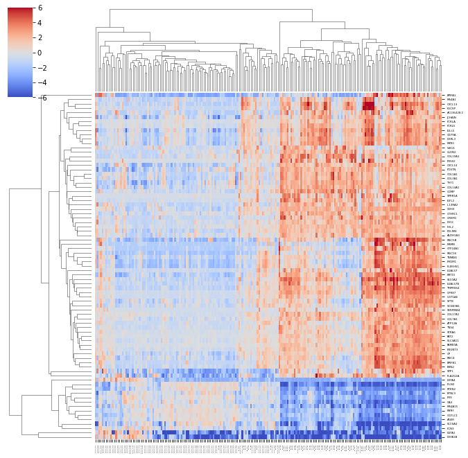

```python
sig_data_log2fc = np.zeros_like(sig_data)

epsilon = 1  # small constant to avoid division by zero


for i in range(len(sig_genes)):

    control_mean =  np.mean(sig_data[i,labels == "control"])

    sig_data_log2fc[i,:] = np.log2((sig_data[i,:]+epsilon) / (control_mean +epsilon))

sns_plot = sns.clustermap(sig_data_log2fc, xticklabels=samples, yticklabels= sig_genes, cmap="coolwarm", vmin=-6, vmax=6)

# changing font sizes for x and y labels
sns_plot.ax_heatmap.set_xticklabels(sns_plot.ax_heatmap.get_xmajorticklabels(), fontsize=2)
sns_plot.ax_heatmap.set_yticklabels(sns_plot.ax_heatmap.get_ymajorticklabels(), fontsize=4)


sns_plot.savefig("output/heatmap.pdf")

plt.show()
```

## Scatter Plot of Gene Expression

This code generates a scatter plot showing the expression levels of a single gene (`POSTN`) across control and IPF samples.

### Steps:

1. **Extract expression data:**  
   The expression values for `POSTN` are separated into control and IPF groups.
2. **Compute summary statistics:**  
   For each group:
   - **Mean** expression is calculated.
   - **Standard error of the mean (SEM)** is calculated as a measure of variability.
3. **Add jitter for visualization:**  
   A small random horizontal offset is applied to each point (`add_jitter`) to prevent overlap and make the distribution of points more visible.
4. **Plot individual points:**
   - Control samples are shown in **blue**.
   - IPF samples are shown in **red**.
   - Point size is small (`s=10`) for clarity.
5. **Add error bars:**
   - The black dots represent the **mean expression** for each group.
   - Error bars indicate the **SEM**, giving an idea of the variability around the mean.
6. **Customize axes and labels:**
   - X-axis: groups (`Control`, `IPF`)
   - Y-axis: expression levels in CPM (counts per million)
   - Title reflects the gene being plotted.
   - Legend distinguishes the two groups.

### Interpretation:

- The scatter plot allows visualization of **individual variability** and the **average expression** between groups.
- Red and blue points show the spread of expression, while error bars summarize central tendency and uncertainty.
- For `POSTN`, we can visually assess whether expression differs between IPF and control samples.

**Note:** Using this type of scatter plot is particularly useful for genes of interest to inspect **outliers, variance, and group-level differences** beyond summary statistics like log2 fold change or p-values.

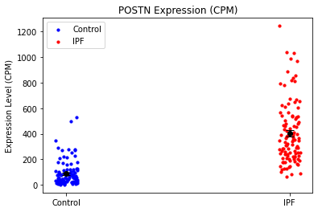

```python
# expression scatter plot

gene_to_plot = "POSTN"

control_expression = data[genes == gene_to_plot, labels == "control"]
ipf_expression = data[genes == gene_to_plot, labels == "ipf"]

control_mean = np.mean(control_expression)
control_sem = np.std(control_expression) / np.sqrt(len(control_expression))
ipf_mean = np.mean(ipf_expression)
ipf_sem = np.std(ipf_expression) / np.sqrt(len(ipf_expression))

def add_jitter(values, jitter_amount=0.05):
    return values + np.random.uniform(-jitter_amount, jitter_amount, size=values.shape)

control_x = add_jitter(np.ones_like(control_expression) * 1)
ipf_x = add_jitter(np.ones_like(ipf_expression) * 2)

plt.scatter(control_x, control_expression, color='blue', label='Control', s=10)  # smaller dots with s=10
plt.scatter(ipf_x, ipf_expression, color='red', label='IPF', s=10)  # smaller dots with s=10

plt.errorbar(1, control_mean, yerr=control_sem, fmt='o', color='black', capsize=5)
plt.errorbar(2, ipf_mean, yerr=ipf_sem, fmt='o', color='black', capsize=5)

plt.xticks([1, 2], ['Control', 'IPF'])

plt.ylabel('Expression Level (CPM)')
plt.title(f'{gene_to_plot} Expression (CPM)')
plt.legend()

# plt.savefig(f"output/{gene_to_plot}_expression_scatter.pdf")
plt.show()
```

## Correlation Heatmap of DEGs

This code generates a heatmap showing the pairwise correlations between differentially expressed genes (DEGs) across all samples.

**Interpretation:**

- The heatmap allows visualization of **co-expression patterns** among DEGs.
- Genes with similar expression patterns across samples cluster together.
- Positive correlations indicate genes that tend to be **up- or down-regulated together**, while negative correlations indicate **opposite expression patterns**.

**Applications:**

- Useful for identifying **modules of co-regulated genes**.
- Can guide hypotheses about shared regulatory mechanisms or pathways among DEGs.

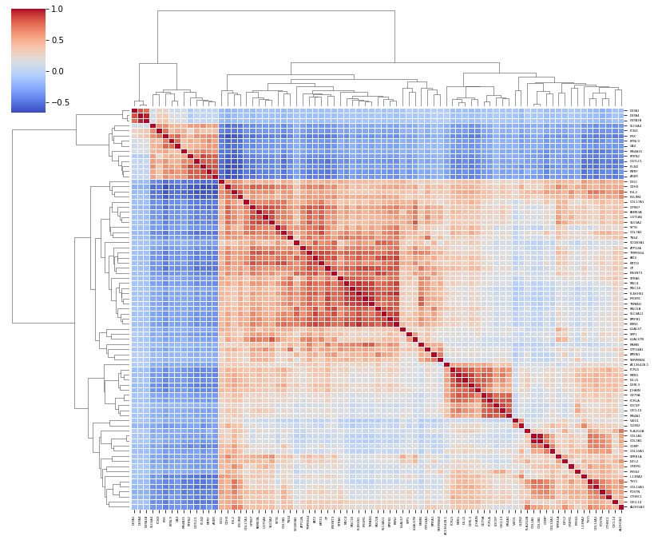

```python
# DEG expression correlation

correlation_matrix = np.corrcoef(sig_data)

sns_plot = sns.clustermap(correlation_matrix,
                          xticklabels=sig_genes,
                          yticklabels=sig_genes,
                          cmap="coolwarm",
                          annot=False,
                          linewidths=.5,
                          figsize=(12, 10))

sns_plot.ax_heatmap.set_xticklabels(sns_plot.ax_heatmap.get_xmajorticklabels(), fontsize=4)
sns_plot.ax_heatmap.set_yticklabels(sns_plot.ax_heatmap.get_ymajorticklabels(), fontsize=4)

sns_plot.savefig("output/degs_correlation_heatmap.pdf")
plt.show()
```